# Preregistration: Subcommunities in Open Science

Author name blinded for review

15. March 2023

# Study Information

## Title

Preregistration: Subcommunities in Open Science

## Description

This project starts with the notion that “Not all open science practices are relevant for all research projects - but for no project open science is irrelevant.” Which open science practices researchers can adopt is determined first and foremost by the nature of the research project itself (e.g., the research interest, design, etc.). This may differ also within disciplines and research paradigms. The scientific landscape is still very heterogeneous in the applicability of open science practices.

It is still unclear what typical applications of open science practices are possible in research. Which open science practices are relevant for all subcommunities and their research projects? Which open science practices differ significantly between subcommunities? How many subcommunities are there and by which profiles of open science practices are they characterized? Answers to these questions support the work of policymakers, scientific societies, research funders, and the researchers themselves.

In an exploratory study, we generate data-driven profiles regarding the use of open science practices to answer these questions.

## Hypotheses

No hypotheses (exploratory).

# Design Plan

## Study type

**Observational Study**.  
Data is collected from study subjects that are not randomly assigned to a treatment. This includes surveys, natural experiments, and regression discontinuity designs.

## Blinding

No blinding is involved in this study.  
There is no treatment/manipulation.

## Study design

We use a cross sectional survey design with one measurement.

## Randomization

No randomization as there is not treatment/manipulation involved.

# Sampling Plan

## Existing data

**Registration prior to creation of data**.  
As of the date of submission of this research plan for preregistration, the data have not yet been collected, created, or realized.

## Explanation of existing data

Not applicable.

## Data collection procedures

Participants are recruited via the online participant recruitment service “[prolific](https://prolific.co/)”. We use quota for the six disciplines based on the OECD-Frascati Manual (Natural Sciences, Engineering and Technology, Medical and Health Sciences, Agricultural Sciences, Social Sciences, Humanities).

## Sample size

We will collect 50 participants from each of the six discipline clusters.  
N = 300

## Sample size rationale

We want to ensure that disciplines are broadly represented, which is why we include the same amount of participants from each discipline cluster. We aim for 300 participants, as this is the threshold needed for Latent Class Analysis. This will enable us to test for up to 7 clusters. If our first analysis points toward seven clusters or more we will collect more data.

## Stopping rule

Not applicable: No sequential analyses.

# Variables

## Manipulated variables

No manipulated variables.

## Measured variables

See codebook with toy data that can also be found in the preregistration.

## Indices

We only use single items.

# Analysis Plan

We will conduct a Latent Class Analysis with the indicators (see codebook):

- `osp_cit`
- `osp_prp`
- `osp_pre`
- `osp_met`
- `osp_sof`
- `osp_mat`
- `osp_cod`
- `osp_dat`
- `osp_oer`
- `osp_opr`
- `osp_oap`
- `osp_oso`
- `osp_sco`

We will report on the distribution of conditional probabilities of classes as well as their pattern on the indicators (via means). We will also report on the distribution of `disc` and `para` within each class.

We will rely on the BIC to select the appropriate number of classes, as simulations have indicated that BIC and aBIC are most suitable (Hagenaars and McCutcheon 2002; Yang 2006).

## Statistical models

See exploratory analyses below.

## Transformations

No transformations.

## Inference criteria

As indicated above, we will use lowest BIC to indicate the number of classes.

## Data exclusion

Participants that took less than 1 minute will be excluded.

## Missing data

All items are mandatory and thus there will be no missing data.

## Exploratory analyses (optional)

```r
library(xfun)
library(here)
library(tidyverse)
library(poLCA)
library(ggridges)
```

Click here to download the toy data if you want to reproduce the results.

```r
# Taken from Niels Ohlsen
# on https://statistics.ohlsen-web.de/latent-class-analysis-polca/

osc_toy <- rio::import(here("data/preregistration_data-toy.RData"))

# define function
f <- with(osc_toy, cbind(osp_cit,
                         osp_prp,
                         osp_pre,
                         osp_met,
                         osp_sof,
                         osp_mat,
                         osp_cod,
                         osp_dat,
                         osp_oer,
                         osp_opr,
                         osp_oap,
                         osp_oso,
                         osp_sco) ~ 1)

# run a sequence of models with 1-7 classes and print out the model with the lowest BIC
max_II <- -100000
min_bic <- 100000
for(i in 2:7){
  lc <- poLCA(f, osc_toy,
              nclass=i,
              maxiter=3000,
              tol=1e-5,
              na.rm=FALSE,
              nrep=10,
              verbose=TRUE,
              calc.se=TRUE)
  if(lc$bic < min_bic){
    min_bic <- lc$bic
    LCA_best_model<-lc
  }
}
```

```r
# extracting best model
LCA_best_model
```

```
## Conditional item response (column) probabilities,
##  by outcome variable, for each class (row)
##
## $osp_cit
##            Pr(1)  Pr(2)  Pr(3)  Pr(4)
## class 1:  0.0198 0.4222 0.4798 0.0782
## class 2:  0.1286 0.4150 0.3368 0.1196
##
## $osp_prp
##            Pr(1)  Pr(2)  Pr(3)  Pr(4)
## class 1:  0.0894 0.2750 0.3704 0.2652
## class 2:  0.1119 0.4031 0.4220 0.0631
##
## $osp_pre
##            Pr(1)  Pr(2)  Pr(3)  Pr(4)
## class 1:  0.1012 0.6690 0.1816 0.0482
## class 2:  0.1214 0.3144 0.4660 0.0983
##
## $osp_met
##            Pr(1)  Pr(2)  Pr(3)  Pr(4)
## class 1:  0.2141 0.3722 0.4137 0.0000
## class 2:  0.0438 0.3997 0.4566 0.0998
##
## $osp_sof
##            Pr(1)  Pr(2)  Pr(3)  Pr(4)
## class 1:  0.1397 0.7548 0.1055 0.0000
## class 2:  0.1358 0.3231 0.4543 0.0868
##
## $osp_mat
##            Pr(1)  Pr(2)  Pr(3)  Pr(4)
## class 1:  0.1421 0.5665 0.2914 0.0000
## class 2:  0.1307 0.2759 0.4545 0.1389
##
## $osp_cod
##            Pr(1)  Pr(2)  Pr(3)  Pr(4)
## class 1:  0.1618 0.3410 0.3258 0.1713
## class 2:  0.0813 0.3744 0.4571 0.0871
##
## $osp_dat
##            Pr(1)  Pr(2)  Pr(3)  Pr(4)
```

[output cut: 32 more lines]

```
##  0.2167 0.7833
##
## =========================================================
## Fit for 2 latent classes:
## =========================================================
## number of observations: 300
## number of estimated parameters: 79
## residual degrees of freedom: 221
## maximum log-likelihood: -4629.083
##
## AIC(2): 9416.166
## BIC(2): 9708.764
## G^2(2): 5835.896 (Likelihood ratio/deviance statistic)
## X^2(2): 99126483 (Chi-square goodness of fit)
##
```

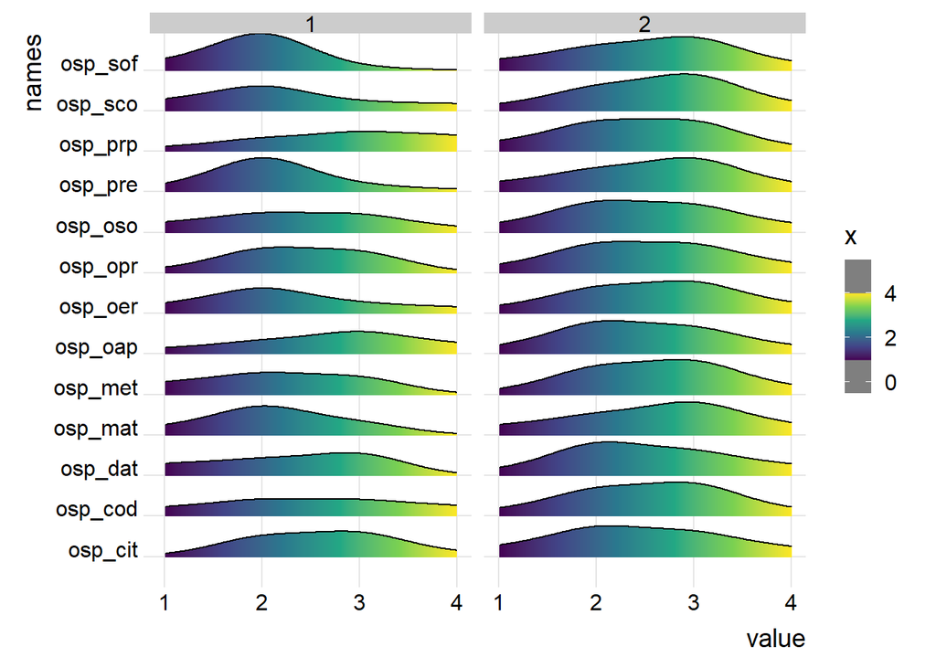

```r
# append class to data set
osc_toy <- data.frame(osc_toy, class = LCA_best_model$predclass)

# plotting density of participants in each class as ridges
osc_toy_plot <- osc_toy %>%
  dplyr::select(-c(disc, para)) %>%
  pivot_longer(1:13, names_to = "names", values_to = "value")

ggplot(osc_toy_plot, aes(x=value, y=names, fill = stat(x))) +
  geom_density_ridges_gradient(scale = 0.9, bandwidth = .5) +
  scale_fill_viridis_c(values = c(.25,.75), option = "D") +
  scale_x_continuous(limits = c(1,4), breaks = c(1,2,3,4)) +
  theme_ridges() +
  facet_wrap(~class)
```

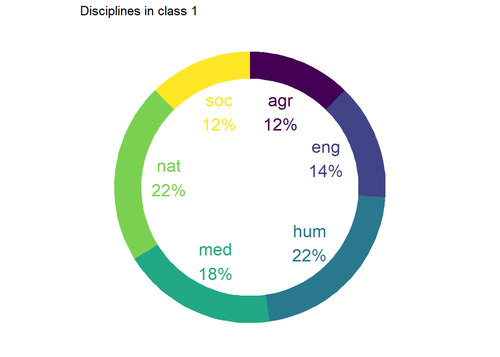

```r
### donut plots ############### #
# disc
osc_toy_disc <- osc_toy %>%
  group_by(class, disc) %>%
  summarize(disc = disc[1],
            disc_n = n()) %>%
  ungroup()

disc_N <- osc_toy_disc %>%
  group_by(class) %>%
  summarize(N = sum(disc_n))

osc_toy_disc <- osc_toy_disc %>%
  mutate(fraction = case_when(
                        class == 1 ~ disc_n/disc_N$N[1],
                        class == 2 ~ disc_n/disc_N$N[2])) %>%
  group_by(class) %>%
  mutate(ymax = cumsum(fraction),
         ymin = c(0, head(ymax, n=-1)),
         labelPosition = (ymax + ymin) / 2,
         label = paste0(disc, "\n", round(fraction * 100), "%"))



# plot for class 1
ggplot(osc_toy_disc%>%filter(class==1), aes(ymax=ymax, ymin=ymin, xmax=4, xmin=3, fill=disc)) +
  geom_rect() +
  geom_text( x=2, aes(y=labelPosition, label=label, color=disc), size=6) + # x here controls label position (inner / outer)
  scale_fill_viridis_d() +
  scale_color_viridis_d() +
  coord_polar(theta="y") +
  xlim(c(-1, 4)) +
  theme_void() +
  theme(legend.position = "none") +
  ggtitle("Disciplines in class 1")
```

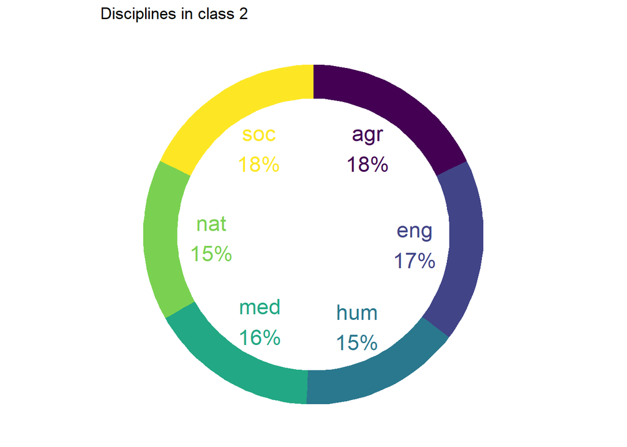

```r
# plot for class 2
ggplot(osc_toy_disc%>%filter(class==2), aes(ymax=ymax, ymin=ymin, xmax=4, xmin=3, fill=disc)) +
  geom_rect() +
  geom_text( x=2, aes(y=labelPosition, label=label, color=disc), size=6) + # x here controls label position (inner / outer)
  scale_fill_viridis_d() +
  scale_color_viridis_d() +
  coord_polar(theta="y") +
  xlim(c(-1, 4)) +
  theme_void() +
  theme(legend.position = "none")+
  ggtitle("Disciplines in class 2")
```

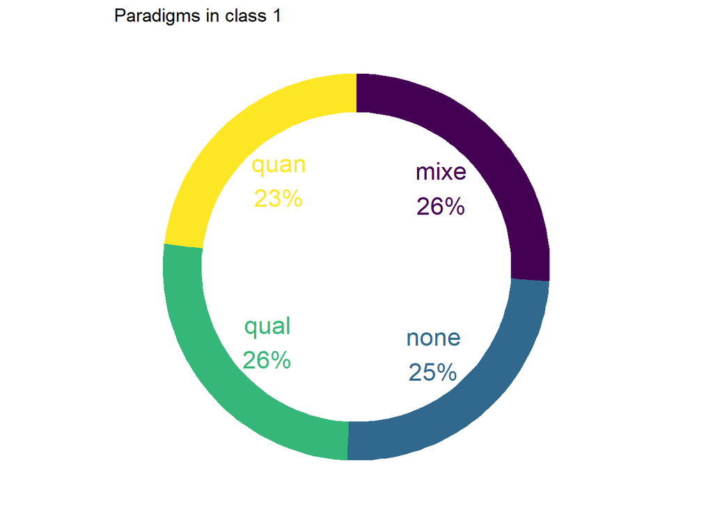

```r
# para
osc_toy_para <- osc_toy %>%
  group_by(class, para) %>%
  summarize(para = para[1],
            para_n = n()) %>%
  ungroup()

para_N <- osc_toy_para %>%
  group_by(class) %>%
  summarize(N = sum(para_n))

osc_toy_para <- osc_toy_para %>%
  mutate(fraction = case_when(
    class == 1 ~ para_n/para_N$N[1],
    class == 2 ~ para_n/para_N$N[2])) %>%
  group_by(class) %>%
  mutate(ymax = cumsum(fraction),
         ymin = c(0, head(ymax, n=-1)),
         labelPosition = (ymax + ymin) / 2,
         label = paste0(para, "\n", round(fraction * 100), "%"))

#plot for class 1
ggplot(osc_toy_para%>%filter(class==1), aes(ymax=ymax, ymin=ymin, xmax=4, xmin=3, fill=para)) +
  geom_rect() +
  geom_text( x=2, aes(y=labelPosition, label=label, color=para), size=6) + # x here controls label position (inner / outer)
  scale_fill_viridis_d() +
  scale_color_viridis_d() +
  coord_polar(theta="y") +
  xlim(c(-1, 4)) +
  theme_void() +
  theme(legend.position = "none") +
  ggtitle("Paradigms in class 1")
```

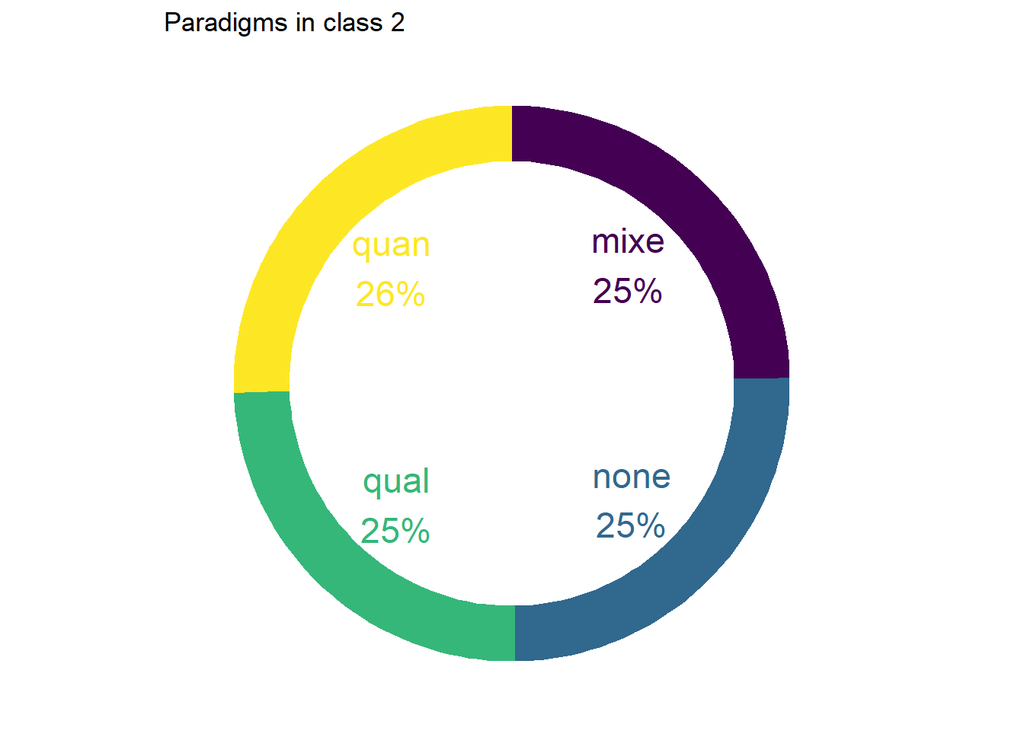

```r
#plot for class 2
ggplot(osc_toy_para%>%filter(class==2), aes(ymax=ymax, ymin=ymin, xmax=4, xmin=3, fill=para)) +
  geom_rect() +
  geom_text( x=2, aes(y=labelPosition, label=label, color=para), size=6) + # x here controls label position (inner / outer)
  scale_fill_viridis_d() +
  scale_color_viridis_d() +
  coord_polar(theta="y") +
  xlim(c(-1, 4)) +
  theme_void() +
  theme(legend.position = "none") +
  ggtitle("Paradigms in class 2")
```

# Other

## Other (Optional)

None.